# Statistical Rethinking: A Bayesian Course with Examples in R and Stan

Chapter 2: Small Worlds and Large Worlds

Marwin Carmo

06/01/2022

# Chapter 2 examples

## 2.4.3. Grid approximation

```r
# define grid
p_grid <- seq( from=0 , to=1 , length.out=20 )
# define prior
prior <- rep( 1 , 20 )
# compute likelihood at each value in grid
likelihood <- dbinom( 6 , size=9 , prob=p_grid )
# compute product of likelihood and prior
unstd.posterior <- likelihood * prior
# standardize the posterior, so it sums to 1
posterior <- unstd.posterior / sum(unstd.posterior)
```

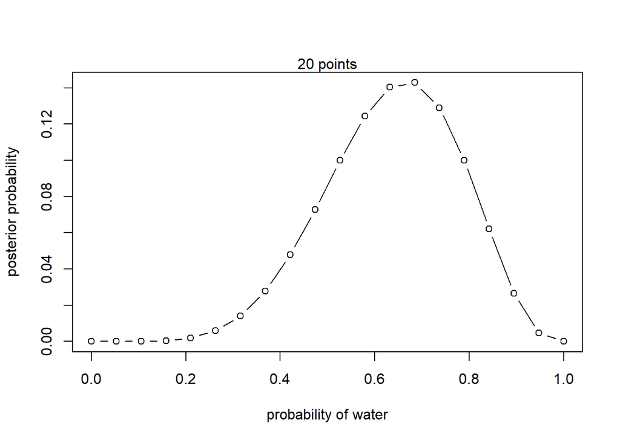

```r
plot( p_grid , posterior , type="b" , xlab="probability of water" , ylab="posterior probability" )
mtext( "20 points" )
```

### Plots with different priors

A step prior, assigning zero probability to all values less than 0.5, results in a truncated posterior

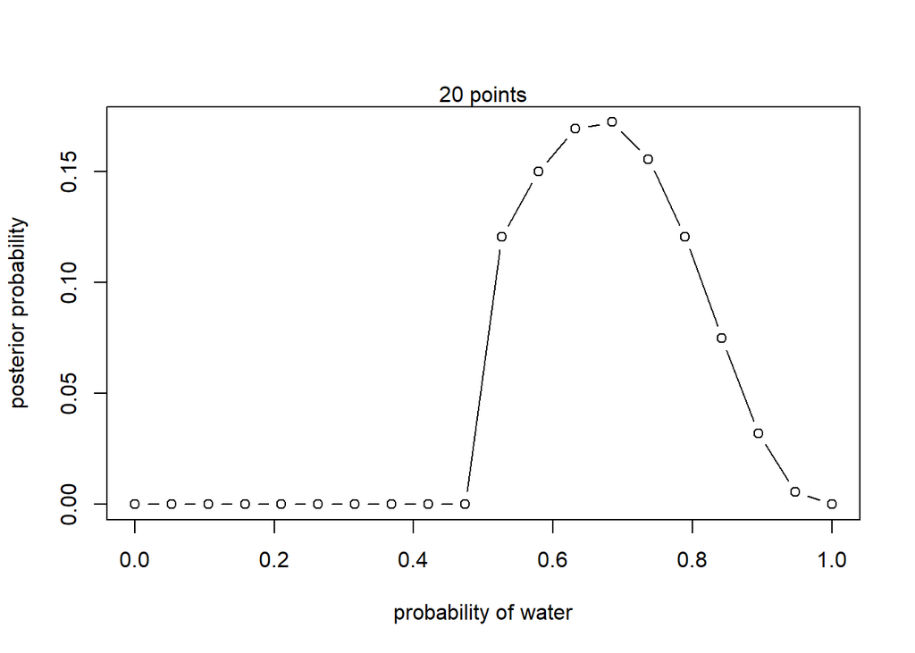

```r
# define grid
p_grid <- seq( from=0 , to=1 , length.out=20 )
# define prior
prior <- ifelse( p_grid < 0.5 , 0 , 1 )
# compute likelihood at each value in grid
likelihood <- dbinom( 6 , size=9 , prob=p_grid )
# compute product of likelihood and prior
unstd.posterior <- likelihood * prior
# standardize the posterior, so it sums to 1
posterior <- unstd.posterior / sum(unstd.posterior)
# plot
plot( p_grid , posterior , type="b" , xlab="probability of water" , ylab="posterior probability" )
mtext( "20 points" )
```

A peaked prior that shifts and skews the posterior, relative to the likelihood.

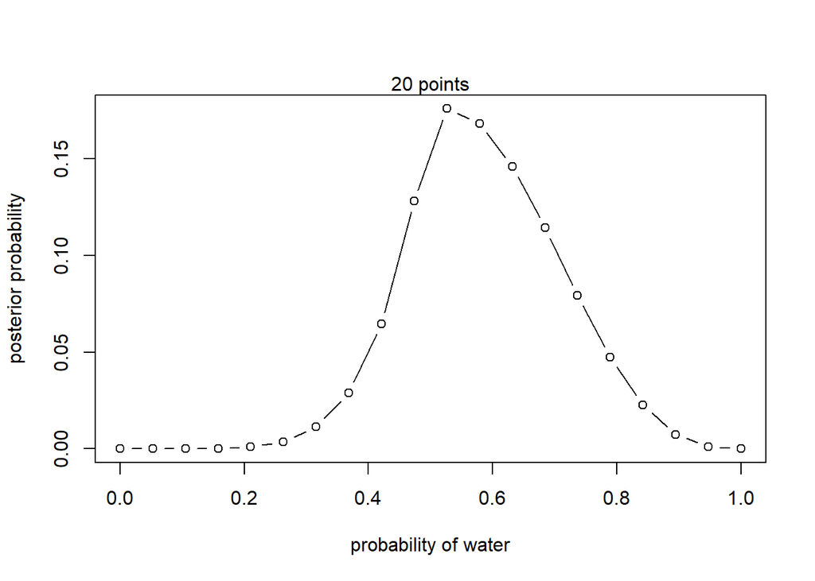

```r
# define grid
p_grid <- seq( from=0 , to=1 , length.out=20 )
# define prior
prior <- exp( -5*abs( p_grid - 0.5 ) )
# compute likelihood at each value in grid
likelihood <- dbinom( 6 , size=9 , prob=p_grid )
# compute product of likelihood and prior
unstd.posterior <- likelihood * prior
# standardize the posterior, so it sums to 1
posterior <- unstd.posterior / sum(unstd.posterior)
# plot
plot( p_grid , posterior , type="b" , xlab="probability of water" , ylab="posterior probability" )
mtext( "20 points" )
```

## 2.4.4. Quadratic approximation

```r
globe.qa <- quap( alist( W ~ dbinom( W+L ,p) , # binomial likelihood
                         p ~ dunif(0,1) # uniform prior
) , data=list(W=6,L=3) )
# display summary of quadratic approximation
precis( globe.qa )
```

```
##        mean       sd      5.5%    94.5%
## p 0.6666701 0.157133 0.4155413 0.917799
```

Assuming the posterior is Gaussian, it is maximized at 0.67, and its standard deviation is 0.16.

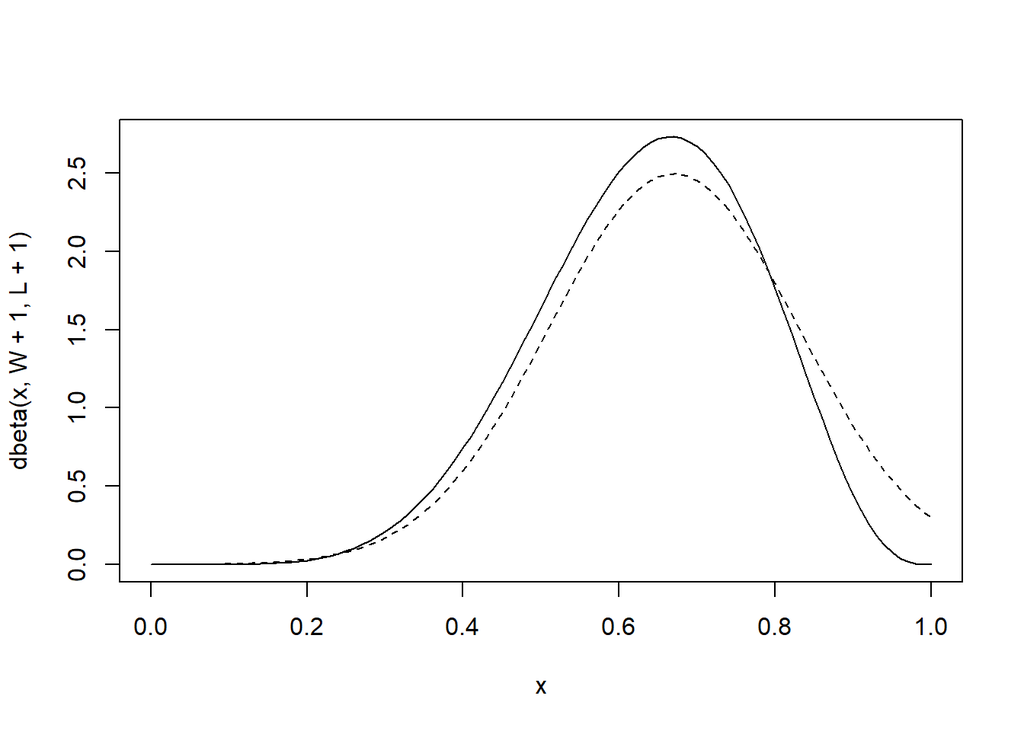

```r
# analytical calculation
W <- 6
L <- 3
curve( dbeta( x , W+1 , L+1 ) , from=0 , to=1 )
# quadratic approximation
curve( dnorm( x , 0.67 , 0.16 ) , lty=2 , add=TRUE )
```

## 2.4.5. Markov chain Monte Carlo

```r
n_samples <- 1000
p <- rep( NA , n_samples )
p[1] <- 0.5
W <- 6
L <- 3
for ( i in 2:n_samples ) {
  p_new <- rnorm( 1 , p[i-1] , 0.1 )
  if ( p_new < 0 ) p_new <- abs( p_new )
  if ( p_new > 1 ) p_new <- 2 - p_new
  q0 <- dbinom( W , W+L , p[i-1] )
  q1 <- dbinom( W , W+L , p_new )
  p[i] <- ifelse( runif(1) < q1/q0 , p_new , p[i-1] )
}
```

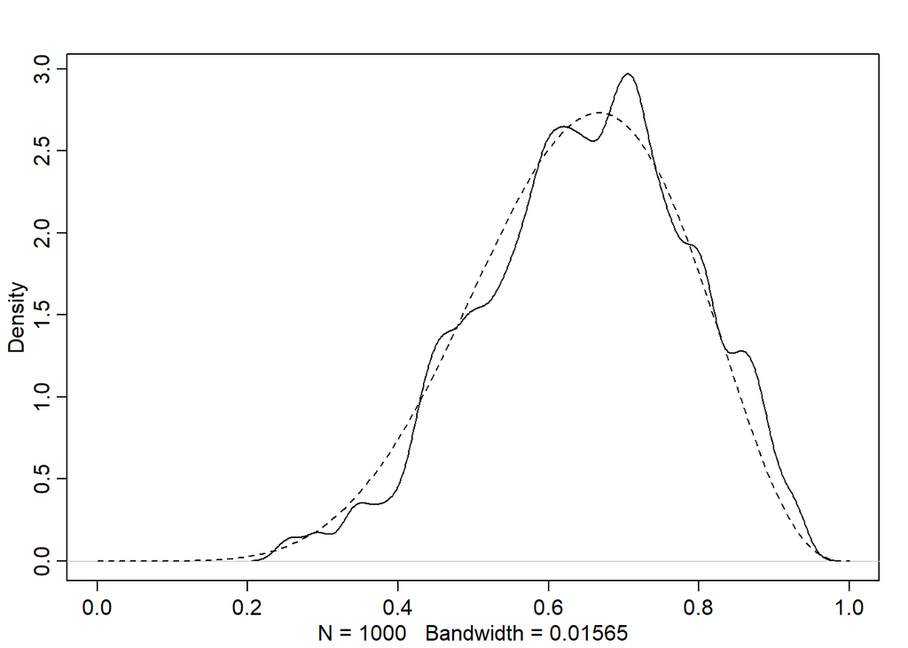

```r
dens( p , xlim=c(0,1) )
curve( dbeta( x , W+1 , L+1 ) , lty=2 , add=TRUE )
```

# 2.6. Practice

### 2E1

Answers (2) and (4): The probability of rain on monday = Pr(rain|Monday) or Pr(rain, Monday)/Pr(Monday)

### 2E2

(3): Pr(Monday|rain) = The probability that it is Monday, given that it is raining.

### 2E3

Answers (1) and (5): the probability that it is Monday, given that it is raining Pr(Monday|rain) = Pr(rain|Monday)Pr(Monday)/Pr(rain)

## 2E4

By stating that probability of water is 0.7 we’re only making an informed guess about the true reality of nature. Probability does not exists because in the real world, things exist or they don’t. The globe is covered by water in a “real” proportion but we can’t know how much it is unless we measure all the land and all the water. Saying that 70% of the globe is water describes only our most plausible estimate given the data we have observed.

## 2M1

Recall the globe tossing model from the chapter. Compute and plot the grid approximate posterior distribution for each of the following sets of observations. In each case, assume a uniform prior for *p*

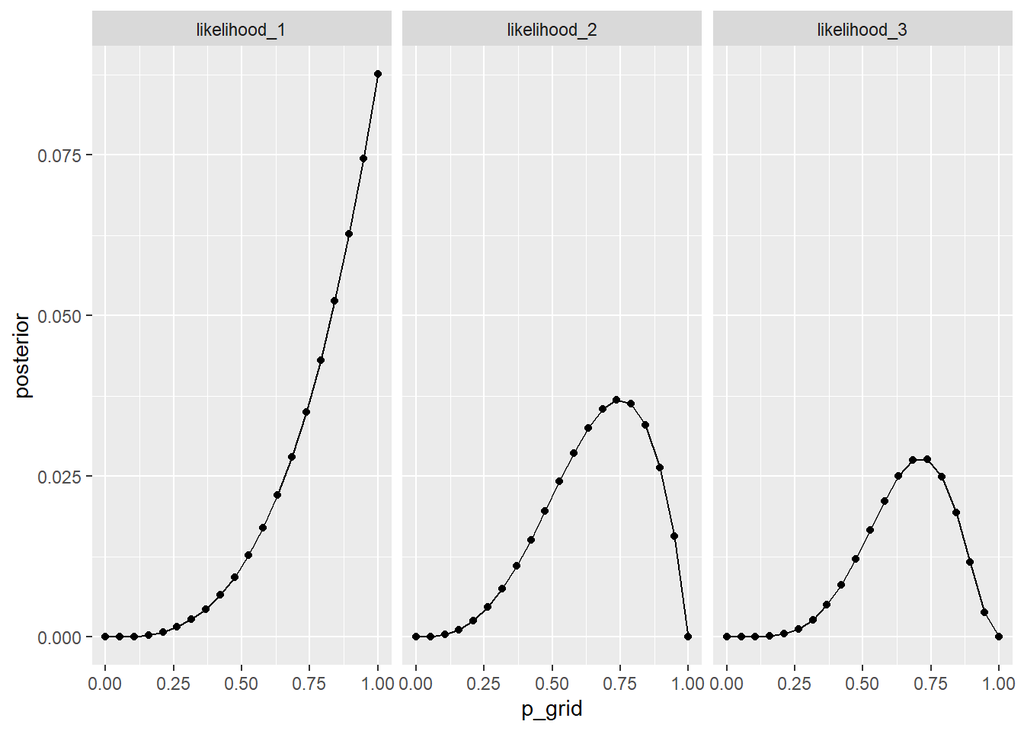

```r
model1 <- tibble::tibble(
  p_grid = seq(from=0, to=1 , length.out=20 ),
  prior = rep( 1 , 20 ),
  likelihood_1 = dbinom(3 , size= 3, prob=p_grid ), # W, W, W
  likelihood_2 = dbinom(3 , size= 4, prob=p_grid ), # W, W, W, L
  likelihood_3 = dbinom(5 , size= 7, prob=p_grid )  # L, W, W, L, W, W, W
) |>
  tidyr::pivot_longer(cols = dplyr::starts_with("likelihood"), values_to = "likelihood", names_to = "sequence") |>
  dplyr::mutate(
    unstd.posterior = likelihood * prior,
    posterior = unstd.posterior / sum(unstd.posterior)
  )

p_model1 <- ggplot(model1, aes(x = p_grid, y = posterior, group = sequence)) +
  geom_line() +
  geom_point() +
  facet_wrap(~ sequence)
p_model1
```

## 2M2

Now assume a prior for p that is equal to zero when p < 0.5 and is a positive constant when p ≥ 0.5. Again compute and plot the grid approximate posterior distribution for each of the sets of observations in the problem just above.

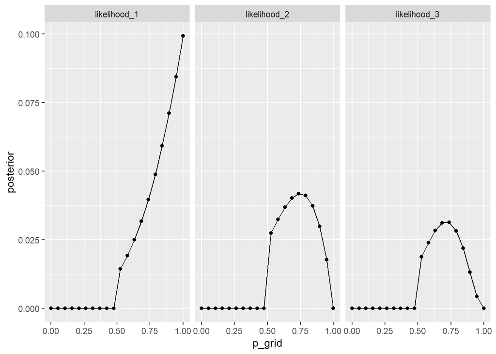

```r
model2 <- tibble::tibble(
  p_grid = seq(from=0, to=1 , length.out=20 ),
  prior = ifelse(p_grid < 0.5, 0, 1),
  likelihood_1 = dbinom(3 , size= 3, prob=p_grid ),
  likelihood_2 = dbinom(3 , size= 4, prob=p_grid ),
  likelihood_3 = dbinom(5 , size= 7, prob=p_grid )
) |>
  tidyr::pivot_longer(cols = dplyr::starts_with("likelihood"), values_to = "likelihood", names_to = "sequence") |>
  dplyr::mutate(
    unstd.posterior = likelihood * prior,
    posterior = unstd.posterior / sum(unstd.posterior)
  )

p_model2 <- ggplot(model2, aes(x = p_grid, y = posterior, group = sequence)) +
  geom_line() +
  geom_point() +
  facet_wrap(~ sequence)
p_model2
```

## 2M3

Suppose there are two globes, one for Earth and one for Mars. The Earth globe is 70% covered in water. The Mars globe is 100% land. Further suppose that one of these globes—you don’t know which—was tossed in the air and produced a “land” observation. Assume that each globe was equally likely to be tossed. Show that the posterior probability that the globe was the Earth, conditional on seeing “land” (Pr(Earth|land)), is 0.23.

```r
PLE <- 0.3 # Pr(Land|Earth)
PLM <- 1.0 # Pr(Land|Mars)
PE <- .5 # Pr(Earth)
PM <- .5 # Pr(Mars)
PL <- PLE * PE + PLM * PM

PEL <- PLE * PE / PL
```

Pr(Earth|land) is equal to 0.23

## 2M4

```r
C1 <- sum(c("B", "B") == "B")  # 2 black sides
C2 <- sum(c("B", "W") == "B") # 1 black 1 white
C3 <- sum(c("W", "W") == "B") # 2 white sides

# ways to produce 1 black
ways <- c(C1,C2,C3)
plausibilities <- ways/sum(ways)
```